# Racial Bechdel Test of Late Night Talk Show

### Introduction

Throughout our lesson on *communication is mediated*, we examined how some stereotypes are structuralized in the entertainment media. On this project, we aim to seek out for racial inequalities in TV shows, especially **Late Night Talk Show**. We looked through top 15 Late Night Talk Show rated by [“ranker.com”](https://www.ranker.com/list/best-current-late-night-shows/ranker-tv), and proceeded to examine each shows meticulously, looking through various clips from *Youtube* and examined how the host talked, deciding if these shows passed our tests.

*Our Bechdel Test look for*:

1. Does the show has or had the host who is people of color?
2. Does the host have accent that is not *standard* White accent?

### Result of the Findings

This table shows the result of the findings:

| Top 15 Late Night Shows | First Test | Second Test |
| --- | --- | --- |
| Last Week Tonight with John Oliver | No | Yes |
| Conan | No | No |
| The Late Show with Stephen Colbert | No | No |
| The Daily Show with Trevor Noah | Yes | Yes |
| The Graham Norton Show | No | No |
| Jimmy Kimmel Live! | No | No |
| The Late Late Show with James Corden | No | No |
| Saturday Night Live | Yes | Yes |
| Late Night with Seth Meyers | No | No |
| The Tonight Show Starring Jimmy Fallon | No | No |
| Real Time with Bill Maher | No | No |
| Gutfeld! | No | No |
| Full Frontal with Samantha Bee | No | No |
| The Not Too Late Show with Elmo | No | Yes |
| Good Talk with Anthony Jeselnik | No | No |

There were only **2** shows which have passed the first test, and only **4** shows which have passed the second test. Only **2** shows passed the both of the test, and **13** shows have failed to do so. The graph of these test results are shown through the bar graphs below.

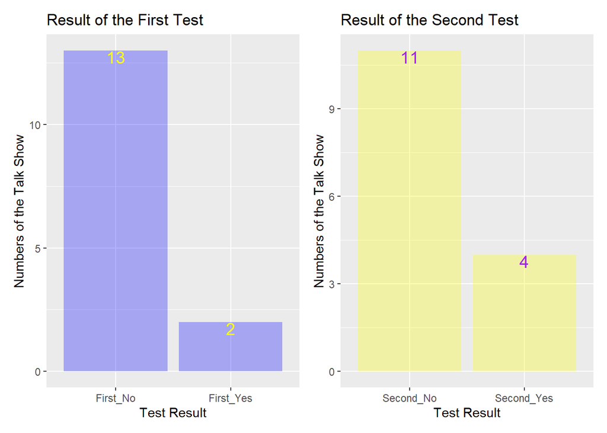

Sadly, it is quite clear that there are still racial inequalities and stereotypes in *Late Night Talk Shows*, where most of the hosts are composed of and expected to be *White* people, rather than people of color.